# Lab4

Tyler Smith & Ritika Agrawal

March 11, 2020

```r
#File Read In
library(readxl)
library(tidyr)
library(dplyr)
```

```r
library(ggplot2)
defense <- read_excel('cyclonesFootball2019.xlsx', sheet='Defensive')
offense <- read_excel('cyclonesFootball2019.xlsx', sheet='Offensive')
bio <- read_excel('cyclonesFootball2019.xlsx', sheet='Biography')
str(bio)
```

```
## Classes 'tbl_df', 'tbl' and 'data.frame':    105 obs. of  7 variables:
##  $ Name      : chr  "Akers, Landen" "Allen, Chase" "Anderson, Ezeriah" "Assalley, Connor" ...
##  $ Position  : chr  "Wide Receiver" "Tight End" "Wide Receiver" "Placekicker" ...
##  $ Height    : chr  "6-0" "6-7" "6-5" "6-0" ...
##  $ Weight    : chr  "188" "245" "204" "195" ...
##  $ Class     : chr  "Redshirt Senior" "Redshirt Senior" "Redshirt Freshman" "Redshirt Senior" ...
##  $ Hometown  : chr  "Cedar Rapids, Iowa" "Nixa, Mo." "Seffner, Fla." "Naperville, Ill." ...
##  $ Highschool: chr  "Washington" "Nixa" "Armwood" "Central" ...
```

# Part One

```r
#Part One

#i
defClean <- defense %>%
  mutate(Name = as.factor(Name),Opponent_Opponent=as.factor(Opponent_Opponent)) %>%
  mutate_at(c("Tackles_Solo","Tackles_ASST","Tackles_TFL","Tackles_Sack","Turnover_FF","Turnover_FR","Turnover_INT","Pass_QBH","Pass_PB"),as.numeric)

offClean <- offense %>%
  mutate(Name = as.factor(Name),Opponent_Opponent=as.factor(Opponent_Opponent)) %>%
  replace_na(list(.=0)) %>%
  mutate_at(c("Rushing_ATT","Rushing_YDS","Rushing_TD","Receiving_REC","Receiving_YDS","Receiving_TD","Passing_CMP-ATT","Passing_YDS","Passing_TD","Passing_INT"),as.numeric)
bioClean <- bio %>%
  separate(col=Height,into=c("Feet","Inches"),sep="-") %>%
  mutate(Name=as.factor(Name),Hometown=as.factor(Hometown),Feet=as.numeric(Feet),Inches=as.numeric(Inches),Weight=as.numeric(Weight)) %>%
  mutate(Height_Inch = Feet*12+Inches) %>%
  select(-Feet,-Inches)

str(defClean)
```

```
## Classes 'tbl_df', 'tbl' and 'data.frame':    502 obs. of  11 variables:
##  $ Name             : Factor w/ 43 levels "Akers, Landen",..: 40 40 40 40 40 40 40 40 40 40 ...
##  $ Opponent_Opponent: Factor w/ 13 levels "Baylor","Iowa",..: 12 2 11 1 8 13 10 7 6 9 ...
##  $ Tackles_Solo     : num  4 4 3 4 3 1 7 3 6 5 ...
##  $ Tackles_ASST     : num  4 7 5 2 2 1 1 2 1 5 ...
##  $ Tackles_TFL      : num  0 0 0 0 1 0 0 0 1 1 ...
##  $ Tackles_Sack     : num  0 0 0 0 0 0 0 0 0 1 ...
##  $ Turnover_FF      : num  0 0 0 0 0 0 0 0 0 0 ...
##  $ Turnover_FR      : num  0 0 0 0 0 0 0 0 0 0 ...
##  $ Turnover_INT     : num  0 0 1 0 0 0 0 0 1 0 ...
##  $ Pass_QBH         : num  1 0 0 0 0 0 0 0 1 0 ...
##  $ Pass_PB          : num  1 2 0 0 0 1 0 0 0 0 ...
```

```r
str(offClean)
```

```
## Classes 'tbl_df', 'tbl' and 'data.frame':    195 obs. of  12 variables:
##  $ Name             : Factor w/ 17 levels "Akers, Landen",..: 1 1 1 1 1 1 1 1 1 1 ...
##  $ Opponent_Opponent: Factor w/ 13 levels "Baylor","Iowa",..: 12 2 11 1 8 13 10 7 6 9 ...
##  $ Rushing_ATT      : num  0 0 1 0 0 0 0 0 0 0 ...
##  $ Rushing_YDS      : num  0 0 8 0 0 0 0 0 0 0 ...
##  $ Rushing_TD       : num  0 0 0 0 0 0 0 0 0 0 ...
##  $ Receiving_REC    : num  1 0 0 0 1 0 0 4 0 1 ...
##  $ Receiving_YDS    : num  21 0 0 0 32 0 0 39 0 7 ...
##  $ Receiving_TD     : num  0 0 0 0 0 0 0 0 0 0 ...
##  $ Passing_CMP-ATT  : num  NA NA NA NA NA NA NA NA NA NA ...
##  $ Passing_YDS      : num  NA NA NA NA NA NA NA NA NA NA ...
##  $ Passing_TD       : num  NA NA NA NA NA NA NA NA NA NA ...
##  $ Passing_INT      : num  NA NA NA NA NA NA NA NA NA NA ...
```

```r
str(bioClean)
```

```
## Classes 'tbl_df', 'tbl' and 'data.frame':    105 obs. of  7 variables:
##  $ Name       : Factor w/ 105 levels "Akers, Landen",..: 1 2 3 4 5 6 7 8 9 10 ...
##  $ Position   : chr  "Wide Receiver" "Tight End" "Wide Receiver" "Placekicker" ...
##  $ Weight     : num  188 245 204 195 190 235 255 285 300 215 ...
##  $ Class      : chr  "Redshirt Senior" "Redshirt Senior" "Redshirt Freshman" "Redshirt Senior" ...
##  $ Hometown   : Factor w/ 86 levels "Akron, Ohio",..: 16 54 73 50 36 20 41 41 86 14 ...
##  $ Highschool : chr  "Washington" "Nixa" "Armwood" "Central" ...
##  $ Height_Inch: num  72 79 77 72 72 75 74 74 72 78 ...
```

# Part 3

### Problem 1

```r
#Part 3
#Problem 1
bo_join <- offClean %>% left_join(bioClean,by="Name")
home <-  bo_join %>%
  select(Name,Hometown) %>% unique
home
```

```
## # A tibble: 17 x 2
##    Name                Hometown
##    <chr>               <fct>
##  1 Akers, Landen       Cedar Rapids, Iowa
##  2 Soehner, Dylan      Prairie Grove, Ark.
##  3 Allen, Chase        Nixa, Mo.
##  4 Wilson, Darren      Alpharetta, Ga.
##  5 Kolar, Charlie      Norman, Okla.
##  6 Pettway, La'Michael <NA>
##  7 Hall, Breece        Wichita, Kan.
##  8 Shaw Jr., Sean      Jones, Okla.
##  9 Purdy, Brock        Gilbert, Ariz.
## 10 Lang, Johnnie       Palmetto, Fla.
## 11 Nwangwu, Kene       Frisco, Texas
## 12 Mitchell, Re-al     <NA>
## 13 Croney Jr., Sheldon <NA>
## 14 Brock, Jirehl       Quincy, Ill.
## 15 Jones, Deshaunte    <NA>
## 16 Milton, Tarique     Bradenton, Fla.
## 17 Scates, Joe         Dayton, Ohio
```

Above is the full list of where offensive players are from. There are a variety of cities and states represented.

### Problem 2

```r
#Problem 2
prob2 <- bo_join %>%
  group_by(Name) %>%
  summarize(rec_yds=sum(Receiving_YDS))
head(prob2)
```

```
## # A tibble: 6 x 2
##   Name                rec_yds
##   <chr>                 <dbl>
## 1 Akers, Landen           109
## 2 Allen, Chase            167
## 3 Brock, Jirehl            NA
## 4 Croney Jr., Sheldon      60
## 5 Hall, Breece            252
## 6 Jones, Deshaunte        877
```

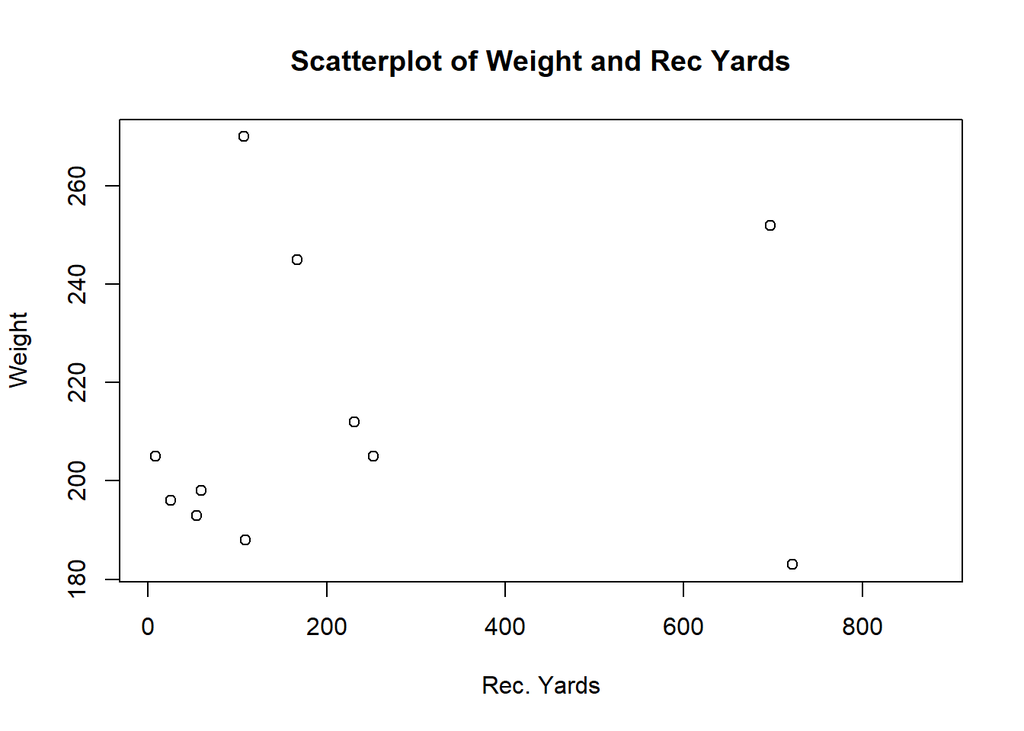

```r
prob2_join <- prob2 %>%
  left_join(bo_join,by="Name") %>%
  select(Name,rec_yds,Weight)
plot(Weight~rec_yds,data=prob2_join,main="Scatterplot of Weight and Rec Yards",xlab="Rec. Yards")
```

### Problem 3

```r
#Problem 3
#,rush_yds = sum(Rushing_YDS,na.rm=T),rush_td = sum(Rushing_TD,na.rm=T)
isu_stats <- offClean %>%
  group_by(Opponent_Opponent) %>%
  summarize(rush_att = sum(as.numeric(Rushing_ATT),na.rm=T),rush_yds = sum(Rushing_YDS,na.rm=T),rush_td = sum(Rushing_TD,na.rm=T))

head(isu_stats)
```

```
## # A tibble: 6 x 4
##   Opponent_Opponent rush_att rush_yds rush_td
##   <fct>                <dbl>    <dbl>   <dbl>
## 1 Baylor                  28       63       1
## 2 Iowa                    19       91       0
## 3 Kansas                  34      118       2
## 4 Kansas State            23       56       1
## 5 Notre Dame              27       45       0
## 6 Oklahoma                37      197       1
```

```r
isu2 <- offClean %>%
  group_by(Opponent_Opponent)
isu_stats
```

```
## # A tibble: 13 x 4
##    Opponent_Opponent rush_att rush_yds rush_td
##    <fct>                <dbl>    <dbl>   <dbl>
##  1 Baylor                  28       63       1
##  2 Iowa                    19       91       0
##  3 Kansas                  34      118       2
##  4 Kansas State            23       56       1
##  5 Notre Dame              27       45       0
##  6 Oklahoma                37      197       1
##  7 Oklahoma State          25       86       2
##  8 TCU                     34      193       4
##  9 Texas                   29      114       0
## 10 Texas Tech              23      186       2
## 11 ULM                     36      274       4
## 12 UNI                     45      185       1
## 13 West Virginia           40      146       4
```

```r
purdy <- offClean %>%
  filter(Name=="Purdy, Brock") %>%
  select(Opponent_Opponent,Passing_YDS)
combined <- isu_stats %>%
  left_join(purdy,by="Opponent_Opponent")
head(combined)
```

```
## # A tibble: 6 x 5
##   Opponent_Opponent rush_att rush_yds rush_td Passing_YDS
##   <fct>                <dbl>    <dbl>   <dbl>       <dbl>
## 1 Baylor                  28       63       1         342
## 2 Iowa                    19       91       0         276
## 3 Kansas                  34      118       2         372
## 4 Kansas State            23       56       1         185
## 5 Notre Dame              27       45       0         222
## 6 Oklahoma                37      197       1         282
```

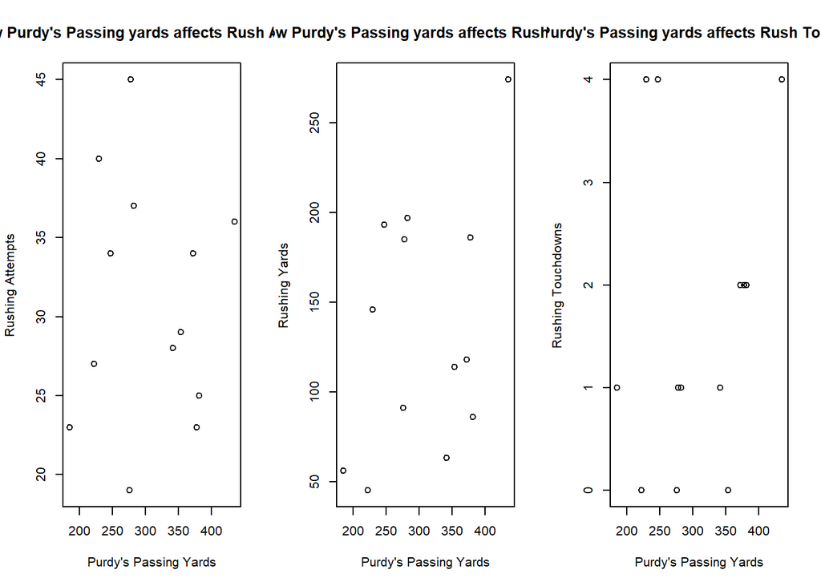

```r
par(mfrow=c(1,3))
plot(data=combined,rush_att~Passing_YDS,main="How Purdy's Passing yards affects Rush Attempts",ylab="Rushing Attempts",xlab="Purdy's Passing Yards")
plot(data=combined,rush_yds~Passing_YDS,main="How Purdy's Passing yards affects Rush Yards",ylab="Rushing Yards",xlab="Purdy's Passing Yards")
plot(data=combined,rush_td~Passing_YDS,main="How Purdy's Passing yards affects Rush Touchdowns",ylab="Rushing Touchdowns",xlab="Purdy's Passing Yards")
```

Above are visuals demonstrating how Brock Purdy’s passing yards affect Iowa State’s rushing numbers. From the first plot, we see that the three games that Iowa State ran the ball the most, Purdy had less than 300 passing yards, a mark he hit in just under half of the games played. The rushing yards showed similar trends, but still appeared to be slightly more random than rushing attempted. The rushing touchdowns seemed to have little to do with Purdy’s passing yards. Purdy’s most pass yards on the season also matched the most rushing touchdowns, while two of his bottom-four games in terms of passing yards had four rushing touchdowns.

### Problem 4

```r
#Problem 4
int_forced <- defClean %>%
  group_by(Opponent_Opponent) %>%
  summarize(def_int = sum(as.numeric(Turnover_INT),na.rm=T))
int_committed <- offClean %>%
  group_by(Opponent_Opponent) %>%
  summarize(off_int = sum(as.numeric(Passing_INT),na.rm=T))
int <- int_forced %>%
  left_join(int_committed,by="Opponent_Opponent")
int
```

```
## # A tibble: 13 x 3
##    Opponent_Opponent def_int off_int
##    <fct>               <dbl>   <dbl>
##  1 Baylor                  0       1
##  2 Iowa                    0       0
##  3 Kansas                  0       1
##  4 Kansas State            1       0
##  5 Notre Dame              0       0
##  6 Oklahoma                1       0
##  7 Oklahoma State          1       3
##  8 TCU                     0       0
##  9 Texas                   0       1
## 10 Texas Tech              0       1
## 11 ULM                     2       1
## 12 UNI                     0       0
## 13 West Virginia           1       1
```

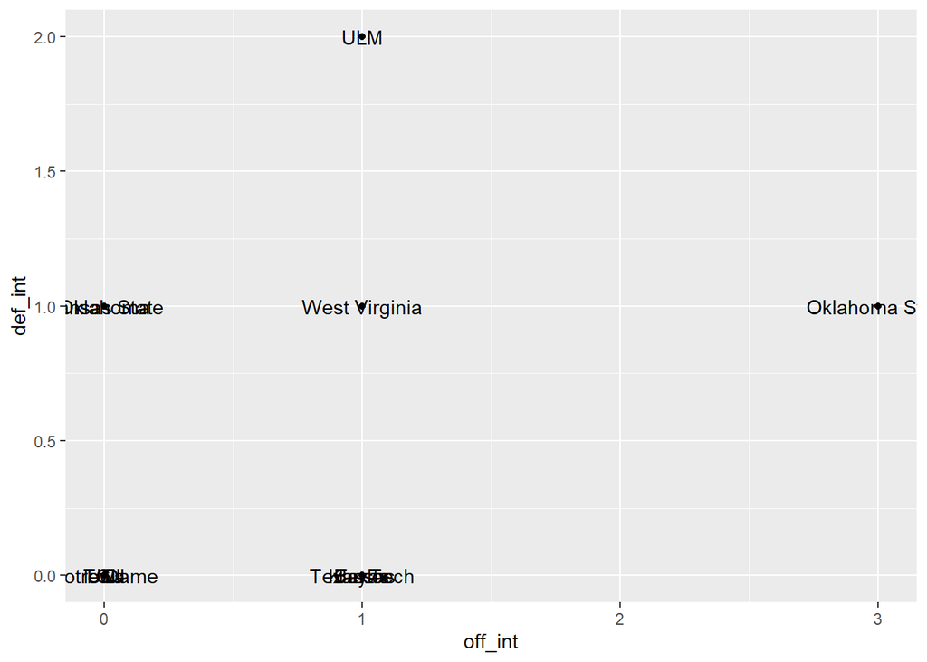

```r
ggplot(int,aes(x=off_int,y=def_int,main="Plot of Interceptions in 2019 Cyclone Football",ylab="Interceptions Forced",xlab="Interceptions Allowed"))+geom_point()+geom_text(aes(label=Opponent_Opponent))
```

```r
#plot(data=int,def_int~off_int,main="Plot of Interceptions in 2019 Cyclone Football",ylab="Interceptions Forced",xlab="Interceptions Allowed")
```

The question we wanted to answer is: Is there any correlation between the number of interceptions forced and committed in a game? (Potentially due to weather conditions in a game)

Answer: The plot above reveals that there were three games in 2019 in which both team had at least one interception allowed. In the two games that featured one team having two or more interceptions, the other team also had an interception, which does spark interest as to whether or not there is some correlation.

Diving deeper into the analysis of the 3+ interception games, the box scores revealed that both games had little-to-no wind and both had temperatures above 50 degrees, which implies weather may not be a huge factor. However, both of these instances happened in Jack Trice Stadium, so perhaps there is something about the stadium that may impact this trend.